# Time series

### **NOTES ON STATISTICS, PROBABILITY and MATHEMATICS**

### Time Series:

A time series **model** can only be built on a stationary time series. Stationary series fulfill the following criteria:

```
1. The mean should be constant, wihtout increasing or decreasing with time.
2. The variance should also be constant along the time line (homoscedasticity).
3. The covariance between terms across a lag (t v. t - m) should not be a function of time.
```

#### **WHITE NOISE:**

White noise is stationary.

$\large y_t = \epsilon_t$

Sequence of identically distributed variables $\epsilon_i$ with $\epsilon_i \sim N(0,\sigma^2)$

Here is an example with plots of the autocorrelation function `acf` telling us how the last value is correlated to the immediate prior values, as well as the partial autocorrelation function `pacf`, showing whether there is any residual correlation of $y_t$ to the prior values of $y$ after eliminating $y_{t-1}$.

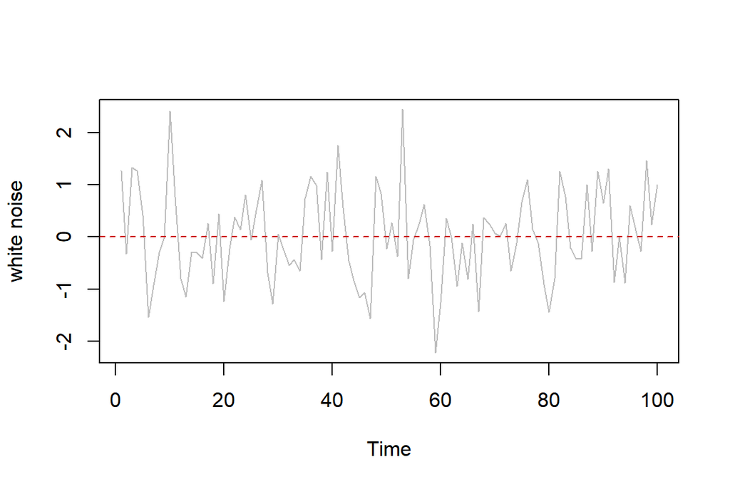

```r
library(cowplot)
library(fpp2)
set.seed(0)

a = rnorm(100)
plot.ts(a, col="gray", ylab="white noise")
abline(h=0, col="red3", lty=2)
```

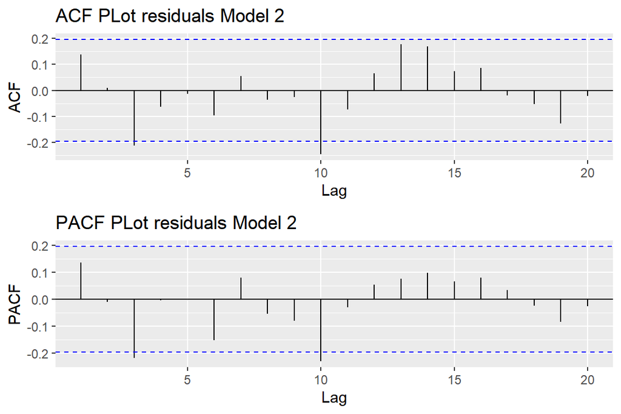

```r
# ACF plot
r1 <- ggAcf(a, lag.max = 20) + labs(title = "ACF PLot residuals Model 2")
# PACF plot
r2 <- ggPacf(a, lag.max = 20) + labs(title = "PACF PLot residuals Model 2")
# Plot both
plot_grid(r1, r2, ncol = 1)
```

#### **RANDOM WALK:**

A random walk is not stationary because the variance is time-dependent: $\text{var}[y_t] = \text{var}[y_o]+\sum_1^t \text{var}[\epsilon_i]= t\, \text{var}[\epsilon].$

$\large y_t = y_{t-1}+\epsilon_t=\epsilon_t+\epsilon_{t-1}+\cdots+\epsilon_1$

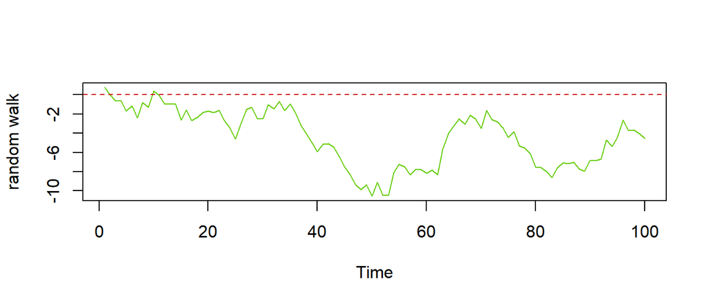

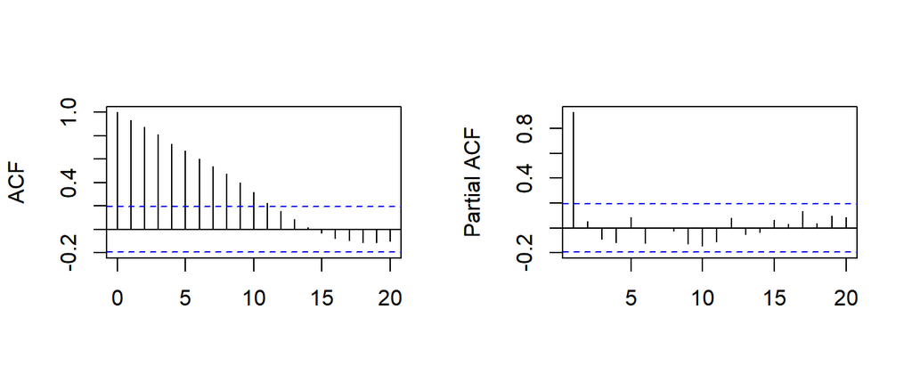

```r
b = cumsum(rnorm(100))
plot.ts(b, col="chartreuse3", ylab="random walk")
abline(h=0, col="red3", lty=2)
```

To simulate the stock market (and aside from more sophisticted autoregressive and moving average effects), the random walk will not be symmetric (equal probabilities). Here is a random walk during an extremely bullish market:

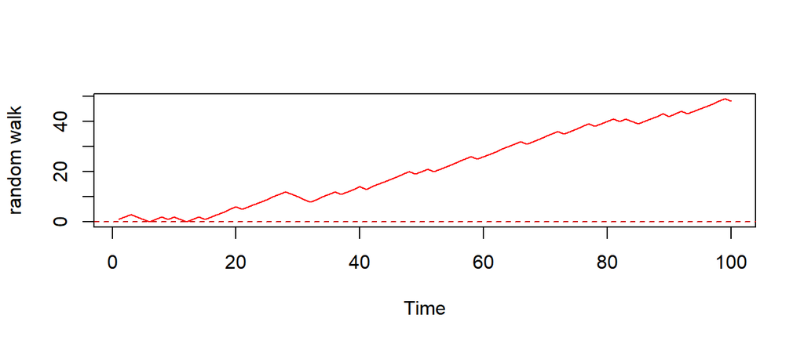

```r
n=100
x = cumsum(sample(c(1,-1), n, prob = c(0.75, 0.25), replace=T))
plot.ts(x, col="red", ylab="random walk")
abline(h=0, col="red3", lty=2)
```

#### **AUTOREGRESSIVE - AR(1):**

$\large \color{blue}{y_t} = c + \color{red}{\rho}\, \color{blue}{y_{t-1}}+\epsilon_t\tag 1$

So notice that $y_t$ is regressed on itself (this is not the case in MA processes). We can recur the equation:

$\large \color{blue}{y_{t-1}} = c + \color{red}{\rho}\, \color{blue}{y_{t-2}}+\epsilon_{t-1}\tag 2$

Substituting 2 into 1:

$\large \color{blue}{y_t} = c + \color{red}{\rho}\, \left ( c + \color{red}{\rho}\, \color{blue}{y_{t-2}}+\epsilon_{t-1} \right)+\epsilon_t= c + \color{red}{\rho}\, c + \color{red}{\rho^2}\, \color{blue}{y_{t-2}} +\color{red}{\rho} \epsilon_{t-1} +\epsilon_t$

This “compound interest” expression is not possible in MA.

When $\rho < 1$ the series is “covariance stationary”. Notice how the influence of the immediate prior position will be, to a certain extent, countered by the effect of $\rho$: the larger $\rho$ is the closer `AR` will be to a random walk; and the smaller it is, the more similar to white noise. $\epsilon_t$ can pull in any direction, but a $\rho < 1$ pulls back $y_{t-1}$ back towards $0$.

After turning a time series into an AR series, we’ll be dealing with a stationary dataset, and we can fit a model by selecting optimal parameters, such as $\rho$.

Leaving the constant $c=0$, and set $\rho=0.6$, here is an example:

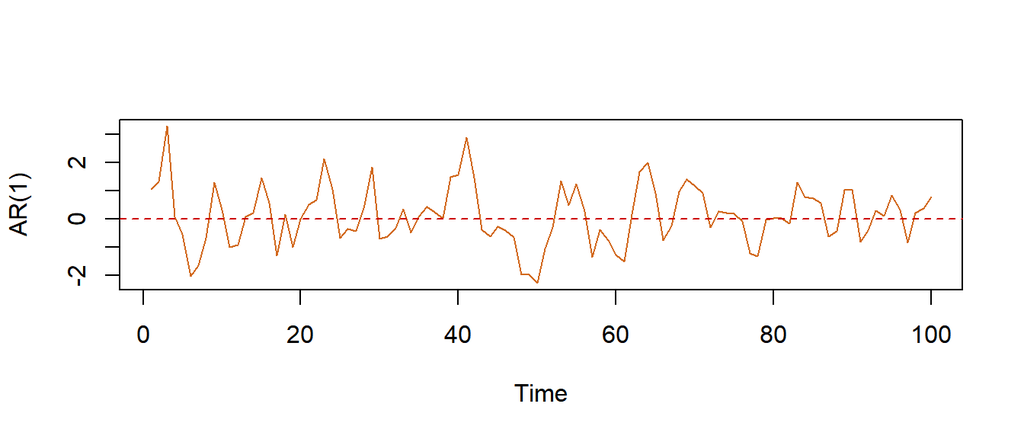

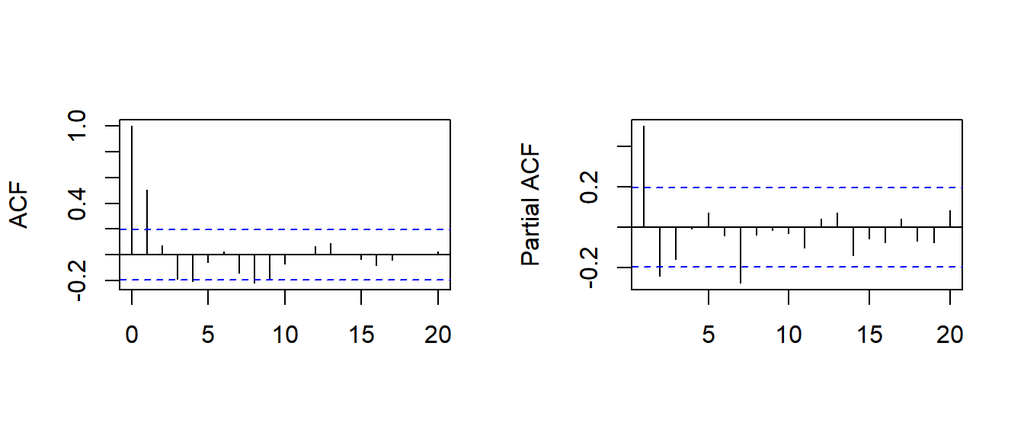

```r
c = arima.sim(n=100,list(ar=0.6),innov=rnorm(100))
plot.ts(c, col="chocolate", ylab="AR(1)")
abline(h=0, col="red3", lty=2)
```

Notice how the lag 1 ($y_{t-1}$) value is significant. But if we suppress this dependency, there is no further correlation upstream (except for some statistical random outliers). Also, the `acf` starts off comparing $t$ to $t$, whereas the first line on the `pacf` plot already compares $t$ to $t-1$.

For any $\text{AR(n)}$:

$\large y_t = \color{red}{\rho_1}\, y_{t-1}+ \color{blue}{\rho_2}\, y_{t-2} +\cdots+ \color{gray}{\rho_n}\, y_{t-n}+ c+\epsilon_t$

In `AR(2)` we have two lags:

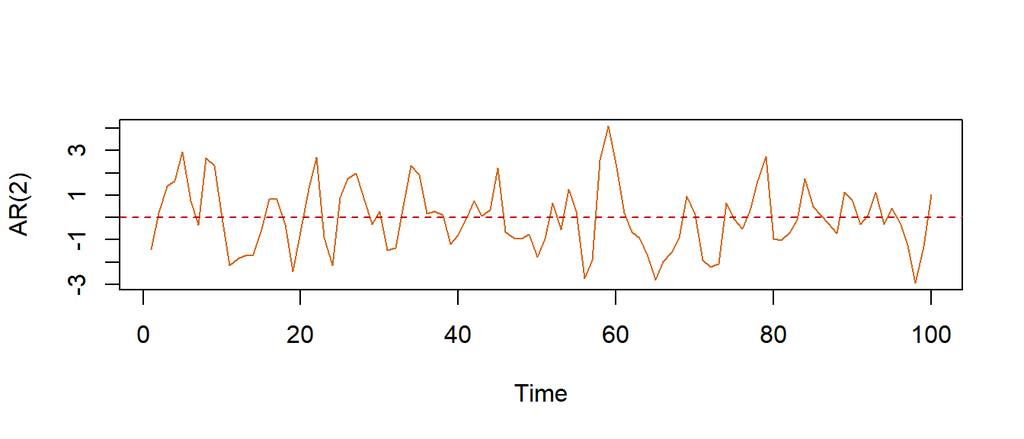

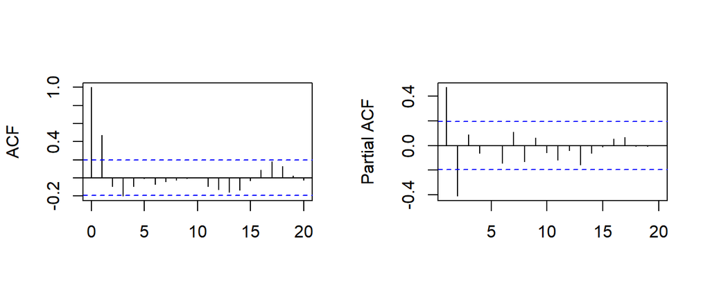

```r
d = arima.sim(n=100,list(ar=c(0.6,-.5)),innov=rnorm(100))
plot.ts(d, col="chocolate", ylab="AR(2)")
abline(h=0, col="red3", lty=2)
```

Notice the negative second lag related to the $-0.5$ AR value. Notice how the acf just gives us a significant correlation without the sign.

#### **MOVING AVERAGE or MA:**

MA is also stationary, and by affecting noise, it’s effects are less long-lived than AR.

$\large\color{blue} {y_t} = k+ \color{red}{\theta}\,\epsilon_{t-1}+\epsilon_t$

which can clearly be extended to $MA(n)$.

Here is an `MA(2)` process:

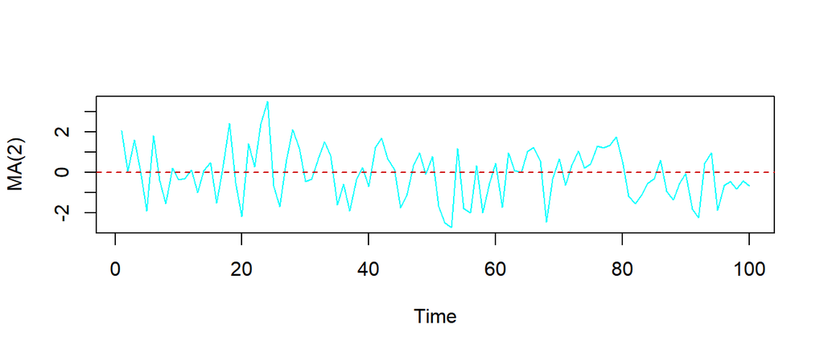

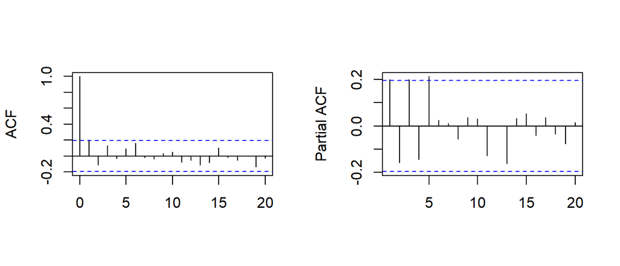

```r
e = arima.sim(n=100,list(ma=c(.88,-.48)),innov=rnorm(100))
plot.ts(e, col="cyan", ylab="MA(2)")
abline(h=0, col="red3", lty=2)
```

#### **MIXED MODELS or ARMA Models:**

$\large y_t = C + \color{red}{\rho_1}\, y_{t-1}+ \color{blue}{\rho_2}\, y_{t-2} +\cdots+ \color{gray}{\rho_n}\, y_{t-n}+ \epsilon_t + \color{red}{\theta_1}\, \epsilon_{t-1}+ \color{blue}{\theta_2}\, \epsilon_{t-2} +\cdots+ \color{gray}{\theta_m}\, y_{t-m}$

Example of ARIMA(2,2):

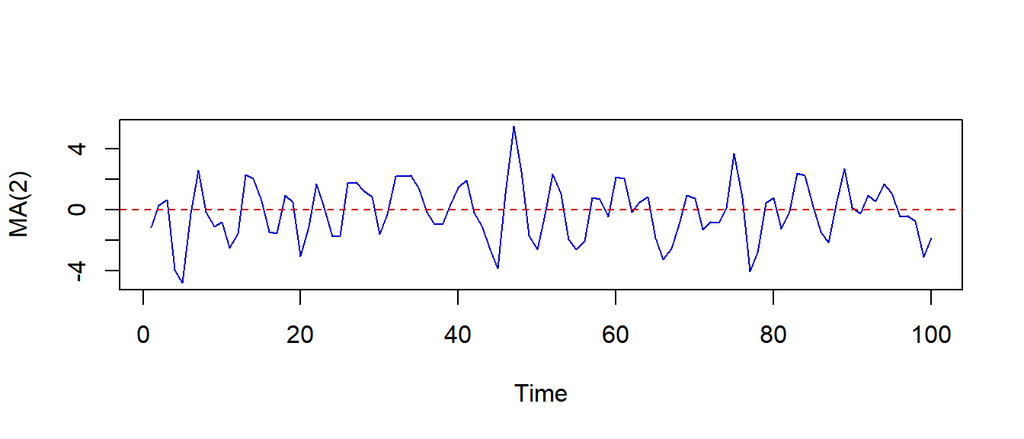

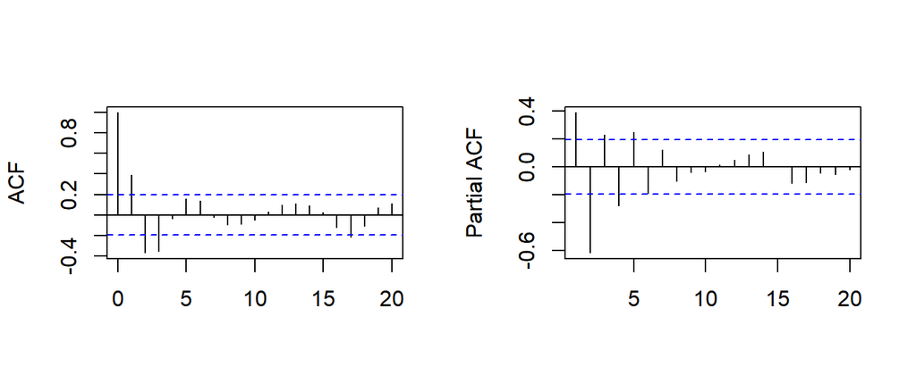

```r
f = arima.sim(n=100,list(ar=c(0.6,-.5), ma=c(.88,-.48)),innov=rnorm(100))
plot.ts(f, col="blue3", ylab="MA(2)")
abline(h=0, col="red3", lty=2)
```

In one single shot:

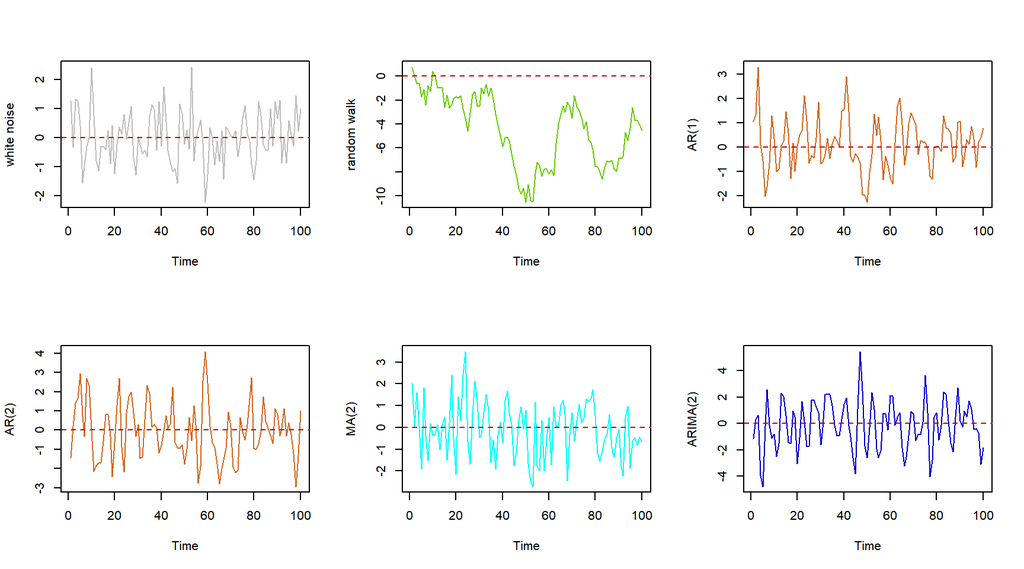

So, after having a stationary dataset, the [two questions to answer](http://www.analyticsvidhya.com/blog/2015/12/complete-tutorial-time-series-modeling/) before fitting a model are:

```
1. Is it an AR or MA process?
2. What order of AR or MA process do we need to use?
```

In a moving average (**MA**) series of lag n, we will not get any correlation between $x(t)$ and $x(t – n -1)$. Hence, the total correlation chart (**ACF**) cuts off at $n$-th lag. So it becomes simple to find the lag for a MA series. For an AR series this correlation will gradually go down without any cut off value.

In an autoregression series (**AR**), the **PACF** will cut off after the degree of AR series: if we have a AR(1) series, if we exclude the effect of 1st lag ($y_{t-1}$) ), our second lag ($y_{t-2}$) ) is independent of $y_t$. Hence, the partial correlation function (PACF) will drop sharply after the 1st lag.

The series can be made stationary with one of the following techniques:

```
1. Detrending
2. Differencing
3. Incorporating seasonality
```

#### Detrending:

$y_t = (\text{mean} + \text{trend} \times t) + \text{error}$

gets rid of the parenthesis part.

#### Differencing:

We model the differences between time points:

$y_t – y_{t-1} = \text{ARMA (p,q)}$

Differencing is called as the Integration part in AR(I)MA. Now, we have three parameters `p : AR; d : I; q : MA`.

#### Seasonality:

Seasonality can easily be incorporated in the ARIMA model directly.

In the case of `AirPassengers`:

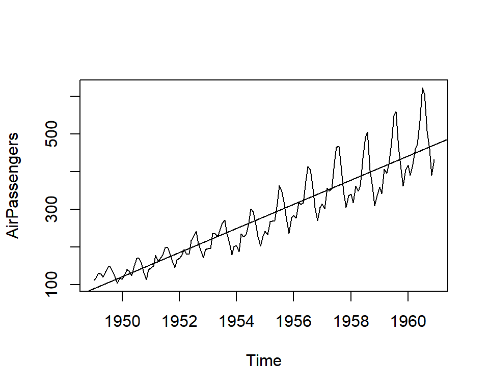

```r
plot.ts(AirPassengers)

abline(lm(AirPassengers~time(AirPassengers)))
```

we can find a **trend** (the upward slope in the time series - solution: taking differences),

```r
lm(AirPassengers~time(AirPassengers))
```

```
##
## Call:
## lm(formula = AirPassengers ~ time(AirPassengers))
##
## Coefficients:
##         (Intercept)  time(AirPassengers)
##           -62055.91                31.89
```

**seasonality**:

```r
x <- ts(AirPassengers, frequency=12) # 12 measurements per year
fit <- tbats(x)
!is.null(fit$seasonal)
```

```
## [1] TRUE
```

and increasing variance (**heteroskedasticity of the time series**) (solution: $\log$).

[output not shown]

```
##
##  Augmented Dickey-Fuller Test
##
## data:  diff(log(AirPassengers))
## Dickey-Fuller = -9.6003, Lag order = 0, p-value = 0.01
## alternative hypothesis: stationary
```

Now the data is stationary. But we still need to find the parameters:

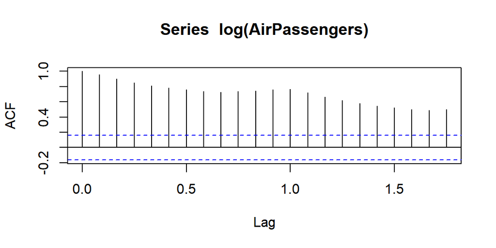

```r
acf(log(AirPassengers))
```

Clearly, the decay of ACF chart on the left is very slow, which means that the population is not stationary.

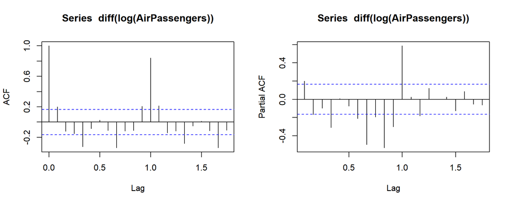

```r
par(mfrow = c(1,2))
acf(diff(log(AirPassengers)))
pacf(diff(log(AirPassengers)))
```

```r
fit = arima(log(AirPassengers), c(0, 1, 1), seasonal = list(order = c(0, 1, 1), period = 12))
```

Now we can predict ten years ahead and plot:

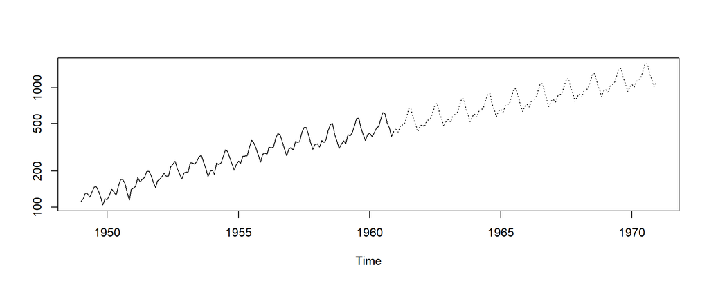

```r
pred <- predict(fit, n.ahead = 10*12)
ts.plot(AirPassengers,exp(pred$pred), log = "y", lty = c(1,3))
```

[Home Page](http://rinterested.github.io/statistics/index.html)

**NOTE: These are tentative notes on different topics for personal use - expect mistakes and misunderstandings.**